# Favoured Model: Mixed effects ordinal regression (stacked data)

## Fit model

Here are all key variables in model.

*Note* I’ve used a rolling average for “EU a good thing” for the years 2015:2017 that were in the spreadsheet.

```r
# Fit model
m1 = clmm(europ2 ~ level * dim + net_bal_pc + goodMu + equi17 + selfrule + vis4 + words + year2 + sourceFormat + (1|country) +  (1|site),
          Hess = TRUE,
          data = df,
          threshold = "flexible")
```

### Summary

```
## Cumulative Link Mixed Model fitted with the Laplace approximation
##
## formula: europ2 ~ level * dim + net_bal_pc + goodMu + equi17 + selfrule +
##     vis4 + words + year2 + sourceFormat + (1 | country) + (1 |      site)
## data:    df
##
##  link  threshold nobs logLik  AIC     niter      max.grad cond.H
##  logit flexible  984  -925.57 1885.14 1568(4887) 3.24e-03 5.6e+06
##
## Random effects:
##  Groups  Name        Variance Std.Dev.
##  site    (Intercept) 0.8027   0.8959
##  country (Intercept) 0.4415   0.6644
## Number of groups:  site 227,  country 8
##
## Coefficients:
##                            Estimate Std. Error z value Pr(>|z|)
## levelNational              1.081535   0.253430   4.268 1.98e-05 ***
## dimPolitics                1.607871   0.290839   5.528 3.23e-08 ***
## net_bal_pc                 0.003669   0.003137   1.170   0.2421
## goodMu                    -1.867810   2.632217  -0.710   0.4780
## equi17                     1.001729   0.567109   1.766   0.0773 .
## selfrule                   0.049100   0.067614   0.726   0.4677
## vis4.L                     0.625496   0.142123   4.401 1.08e-05 ***
## vis4.Q                    -0.064032   0.121286  -0.528   0.5975
## words500-1000              0.317395   0.157540   2.015   0.0439 *
## words+1000                 0.459194   0.269542   1.704   0.0885 .
## year2                      0.088349   0.101690   0.869   0.3850
## sourceFormatOnline only   -0.133491   0.215861  -0.618   0.5363
## levelNational:dimPolitics -0.677232   0.331434  -2.043   0.0410 *
## ---
## Signif. codes:  0 '***' 0.001 '**' 0.01 '*' 0.05 '.' 0.1 ' ' 1
##
## Threshold coefficients:
##             Estimate Std. Error z value
## None|Medium   0.3652     1.3087   0.279
## Medium|High   2.4792     1.3122   1.889
## (1 observation deleted due to missingness)
```

Here’s the regression output in tidy format focusing on key variables. So in this model the EXACT same 3 variables are signficant as in the TONE regression: Frames, Level and Word length of story -although the latter to a much lesser degree. In addition, Visibility pops in too (check on that later).

### Regression in tidy output

|  | Dependent Variable: Europeanization |
| --- | --- |
| Level:National | 1.082 *** (4.268) |
| Frame:Politics | 1.608 *** (5.528) |
| Net balance p.c. | 0.004 (1.170) |
| EU good thing (average) | -1.868 (-0.710) |
| Quality governance | 1.002 (1.766) |
| Level self rule | 0.049 (0.726) |
| Visibility: very low \| low/medium | 0.625 *** (4.401) |
| Visibility: low/medium \| high | -0.064 (-0.528) |
| Word length (500:1000) | 0.317 * (2.015) |
| Word length (+1000) | 0.459 (1.704) |
| Year | 0.088 (0.869) |
| Type:Web native | -0.133 (-0.618) |
| Level * Frames | -0.677 * (-2.043) |
| Mixed effects ordinal regression (z values in brackets). Significant coefficients <0.05 in bold. P-value signficance levels: *** p < 0.001; ** p < 0.01; * p < 0.05. |  |

### Plot main regression results

We have somewhat cleaner results for the Europeanization question in terms of level and the interaction with Frame.

Beginning with the no interaction model it looks like No Europ_ is more unlikely at the national level; on the other hand High Europ_ is less likely at the regional level.

The interaction effect by Frames add some nuance to this. For Economic frames there is a big difference between Regional and National - much more likely to be No Europ_ at the regional level than national. There is also a difference on the medium Europ_ between the two for the Economics frame (more Europ_ for the national); and similarly for High Europ_.

Basically, the differences seem to be mostly driven by the Economics frame -Politics exhibit less difference.

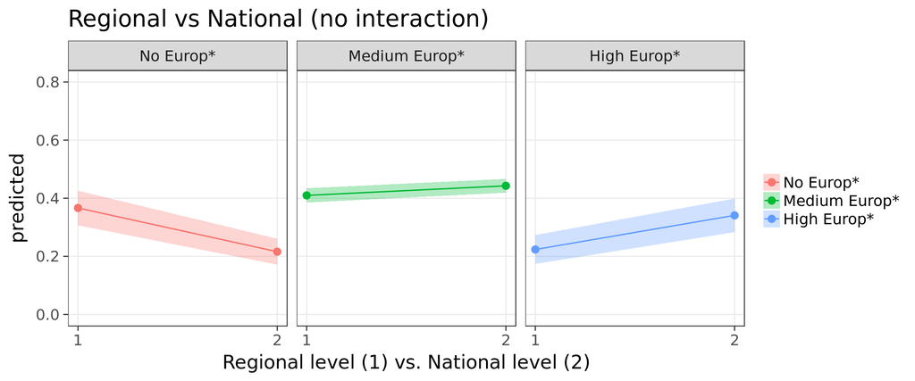

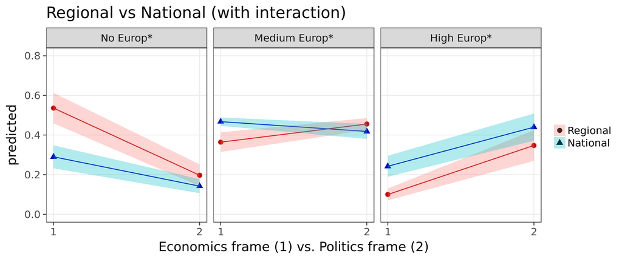

# Annex

Let’s just check what is happening with the other two variables.

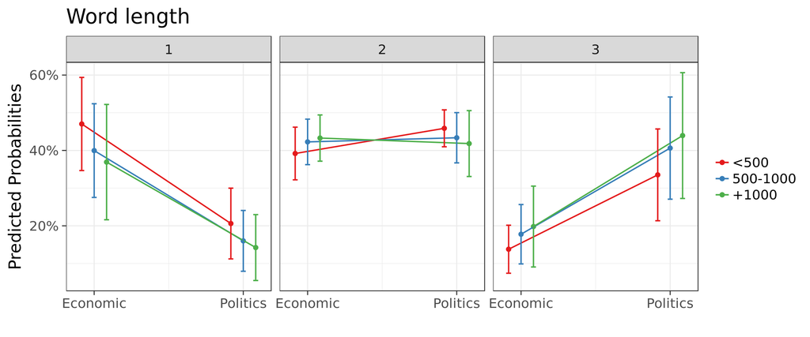

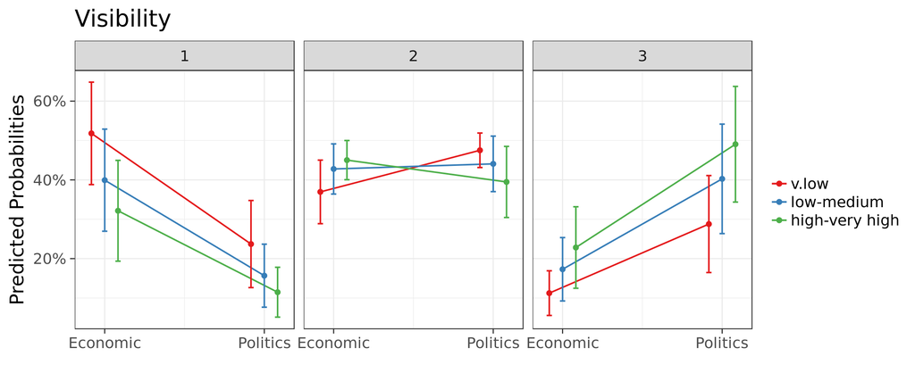